# Survival of the selfish: Contrasting self-referential and survival-based encoding - ScienceDirect

Brought to you by:Brooklyn College Library, CUNY

- [View **PDF**](https://www.sciencedirect.com/science/article/pii/S1053810012002395/pdfft?md5=e2d862b1dfef2fa6831d4f79f323258e&pid=1-s2.0-S1053810012002395-main.pdf)

## Cited By (23)

## Figures (3)

## Tables (1)

1. Table 1

## [Consciousness and Cognition](https://www.sciencedirect.com/journal/consciousness-and-cognition)

[Volume 22, Issue 1](https://www.sciencedirect.com/journal/consciousness-and-cognition/vol/22/issue/1), March 2013, Pages 237-244

# Short Communication Survival of the selfish: Contrasting self-referential and survival-based encoding

, , ,

https://doi.org/10.1016/j.concog.2012.12.005[Get rights and content](https://s100.copyright.com/AppDispatchServlet?publisherName=ELS&contentID=S1053810012002395&orderBeanReset=true)

## Abstract

Processing information in the context of personal survival scenarios elicits a memory advantage, relative to other rich encoding conditions such as self-referencing. However, previous research is unable to distinguish between the influence of survival and self-reference because *personal* survival is a self-referent encoding context. To resolve this issue, participants in the current study processed items in the context of their own survival and a familiar other person’s survival, as well as in a semantic context. Recognition memory for the items revealed that personal survival elicited a memory advantage relative to semantic encoding, whereas other-survival did not. These findings reinforce suggestions that the survival effect is closely tied with self-referential encoding, ensuring that fitness information of potential importance to self is successfully retained in memory.

### Highlights

► Research on survival-related memory effects is confounded with self-referencing. ► We show that survival encoding scenarios only elicit a memory advantage when they are self-referential. ► This suggests the self is at the centre of memory biases, consistent with ecological accounts.

## Keywords

Memory

Self

Self-reference effect

Survival

Fitness value

## 1. Introduction

### 1.1. Survival-related processing

Memory researchers have identified adaptive qualities of encoding and retrieval that allow fitness information (i.e., that concerning survival and reproduction) to be preferentially processed (Kang et al., 2008, Klein et al., 2002, Nairne, 2005, Nairne and Pandeirada, 2008a, Nairne and Pandeirada, 2008b, Nairne and Pandeirada, 2010, Nairne et al., 2007, New et al., 2007, Öhman and Mineka, 2001). It is posited that ecological pressures have led to the evolution of specific processing biases in relevant domains such as physical survival (i.e., food, shelter, and danger), navigation, reproduction, social exchange, and kinship (Nairne & Pandeirada, 2008b). Of these domains, memory research has focused on physical survival-related processing, demonstrating a robust memory advantage for items encoded in a survival context over non-survival related items (e.g., Burns et al., 2011, Kang et al., 2008, Nairne and Pandeirada, 2008a, Nairne and Pandeirada, 2008b, Nairne et al., 2007, Weinstein et al., 2008, Öhman and Mineka, 2001).

The body of research on survival-related memory has grown from a paradigm developed by Nairne et al. (2007). In this study, participants were asked to rate items for importance in the context of a surviving in a foreign grassland, before their item memory was assessed. Memory for this ‘survival-related’ information was contrasted with memory for information encoded in a non-survival related context (rating the importance of items if moving to a new home abroad), and other contexts known to elicit superior memory performance (rating words for pleasantness and self-relevance). Nairne et al. found that compared to all the non-survival related tasks tested, the survival-based encoding led to higher recall and recognition, suggesting that memory systems are indeed ‘tuned’ for fitness value.

Consolidating this conclusion, some subsequent studies have shown that the memory advantage associated with survival-based encoding is maximized in contexts that mimic the hunter-gatherer environment (i.e., the ‘environment of evolutionary adaptedness’ (EEA) – see Foley, 1995). For example, survival-related processing elicits a greater advantage when ancient grasslands rather than modern city contexts are evoked at encoding (Nairne and Pandeirada, 2010, Weinstein et al., 2008), and when specific hunter-gatherer goals are involved (e.g., searching in the grasslands for food to eat v. searching for the same items in a team scavenging game – Nairne, Pandeirada, Gregory, & Van Arsdall, 2009). However, recent research has questioned whether evoking the EEA is a necessary prerequisite for the survival effect on memory, with non-grasslands scenarios (e.g., going a picnic) evoking a similar memory advantage (Klein, 2012). Notwithstanding the relative importance of EEA scenarios, these studies together build a compelling argument for the existence of an adaptive, context-dependent encoding bias that ensures information relating to personal survival is successfully retained.

### 1.2. The self in survival

An interesting aspect of the memory bias for survival-related information, and the focus of the current inquiry, is the extent to which it is associated with self-referential processing biases (see Burns et al., 2011, Klein, 2012). As Nairne et al. (2007) acknowledge, processing personal survival is clearly a self-referential encoding context. Indeed, as Klein comments, “few things are *more* self-relevant than one’s own survival” (2012, p. 2, emphasis added).

This self-processing and survival-processing conflation is of theoretical interest because encoding information in a context of self-relevance also elicits a strong memory bias (the self-reference effect (SRE) in memory – Rogers, Kuiper, & Kirker, 1977). The SRE has received an enormous amount of empirical attention for more than three decades, so that we now have a rich understanding of the mechanisms through which it is elicited (for review, see Symons & Johnson, 1997). There is evidence that self-referencing promotes better organization in memory, and leads to relatively rich representations due to elaboration by the detailed and accessible self-concept (Klein and Kihlstrom, 1986, Klein and Loftus, 1988, Symons and Johnson, 1997). Recent research also suggests that automatic responses to self-reference such as increased attention and physiological arousal may also contribute to the rich, elaborative encoding that characterizes self-referential memories (Turk et al., 2008, Turk, Van Bussel, Waiter, et al., 2011, Turk, Van Bussel, Brebner, et al., 2011). If the survival effect is related to self-referential processing, then such explanations could provide a useful account of the proximate mechanisms underlying the impact of survival-related encoding on memory.

Nairne et al. (2007) make the valid point that survival-related retention in their experiments exceeded control conditions that evoked self-reference (i.e., deciding what items would be necessary for a *personal* move abroad). However, Klein (2012) has pointed out concerns with these tasks. In particular, the self-referencing task used by Nairne et al. may have failed to elicit self-referential memories because participants were asked to rate the likelihood of items evoking [autobiographical memories](https://www.sciencedirect.com/topics/neuroscience/episodic-memory), rather than instructed to recall the memories themselves. Klein replicated Nairne et al.’s experiments using a more standard self-referential instructions and found that the memory advantage for survival-based over self-referential processing was rendered non-significant.

Interestingly, the effect of ‘removing’ the self from survival tasks has been explored previously. Weinstein et al. (2008) employed a between groups design to contrast memory from both first and third-person survival encoding tasks (i.e., rating words in relation to survival of self, friend or a stranger), and found a similar effect in each referent condition. Further, Kang et al. (2008) found that processing information in terms of its fitness for survival enhanced memory performance even when the referent was a cartoon character. However, an issue with both of these studies is that they use a between groups design – when participants are imaging what another person would do in a survival context that is unfamiliar to them, it is likely that they would project self to complete the task (i.e., *“If it were me trying to survive, I would need…”*). It may be that the utilization of a between groups design does not elicit the necessary self-other distinction at encoding (see Greene, 1996, Greenwald, 1976). The current inquiry seeks to overcome this issue and provide a direct test of the influence of self-referential versus survival-based encoding on subsequent memory.

### 1.3. The current inquiry

This inquiry sought to directly compare self- and other-survival using a variation of Nairne et al.’s (2007) grassland survival task. In a repeated-measures experiment, participants were asked to rate the usefulness of items in the context of their *own* survival in a grasslands context, or the survival of a familiar *other* person. A semantic encoding context was also included for contrast. By specifically generating the need for a self versus other contrast at encoding we predicted that an advantage for survival-related processing over [semantic processing](https://www.sciencedirect.com/topics/psychology/semantic-processing) would be found when the referent is self, which would be attenuated or eliminated in the other-referent condition. An addition feature was the use of a recognition memory measure rather than free recall, to assess memory performance without relying on only recollective experience (see Symons & Johnson, 1997).

## 2. Method

### 2.1. Participants and design

Forty undergraduate students (25 females, mean age 19.1 years) from the University of Aberdeen took part in the experiment in return for course credits. All participants had normal or corrected-to-normal eyesight. Participants gave informed consent in accordance with the guidelines set by the University of Aberdeen’s Psychology Ethics Committee. A single-factor (Encoding condition: Self, Other, Semantic) within-subjects design was employed.

### 2.2. Procedure and stimulus materials

Participants were tested individually and the experiment was delivered using E-prime version 1.1 experimental software (Psychology Software Tools Inc., Pittsburgh, PA). A total of 180 objects derived from the Clark and Paivio (2004) norms, were sorted into six lists of 30 items each, matched for familiarity, imagery and frequency. At encoding, one list was presented in a ‘self’ condition block, one in the ‘other’ condition block and one in the ‘semantic’ condition block. The three remaining lists were reserved for use as foils in the subsequent recognition test. The use of lists as self, other, semantic or test lists was counterbalanced across participants. Block order was also counterbalanced across participants, and item order was randomised within each block. Instructions as to how the items should be rated were given at the start of each block and were as follows:

> *Other condition*: “In this task, try to imagine that David Cameron is stranded in the grasslands of a foreign land, without basic survival materials. Over the next few months he will need to find steady supplies of food, water and protect himself from predators. You will now be shown a list of words and you are asked to rate their relevance to David Cameron’s survival situation on a scale of 1–5 (1 being not relevant and 5 being extremely relevant). Some of the words may be relevant and others may not. It is up to you to decide.”

> *Semantic condition*:“In this task, you will be presented with a series of words, some of these items can be found in the city, others in nature or sometimes in both. You will be asked to rate these words as follows: 1 = Only found in the city, 2 = Mostly found in the city, 3 = Found in both city and nature, 4 = Mostly found in nature, 5 = Only found in nature. It is up to you to decide.”

Participants entered their responses via a keypress. Following the encoding phase, participants performed a 10-min digit recall filler task, after which a self-paced surprise recognition test was administered. The 90 previously-presented (Old) items and 90 New items were presented individually in a random order. Participants responded with an Old or New keypress.

## 3. Results

Eight participants demonstrated poor performance on the rating task with more than 10% of words in any condition being unrated within the timeframe allowed. Analysis was therefore confined to the 32 remaining participants.

### 3.1. Recognition accuracy data

Proportional hit scores and false alarm scores calculated and transformed to accuracy scores to correct for guessing<sup>2</sup> (see Table 1 for uncorrected hit rates and false alarm rates). These scores were submitted to a single factor ANOVA (encoding condition: self, other, semantic). Mauchly’s test indicated that the assumption of sphericity had been violated (χ<sup>2</sup>(2) = 16.8, *p* < .001), therefore degrees of freedom were corrected using Greenhouse-Geisser estimates of sphericity (*ε* = .78). This showed a significant main effect of encoding condition, *F*(1.57, 48.72) = 9.03, *p* = .001, *η*<sup>2</sup> = .23, see Fig. 1A. Planned contrasts indicated significant differences between the self-survival and other-survival condition, *t*(31) = 2.76, *p* = .01, and between the self-survival condition and semantic condition, *t*(31) = 5.85, *p* < .001. However, there was no observed difference in memory performance between the other-survival and semantic condition, *t*(31) *=* 1.04, *p* = .31. These results indicate that memory performance is significantly better following self-survival encoding than following either other-survival or semantic encoding. The other-survival scenario did not elicit a memory advantage.

Table 1. False alarm rates and hit (uncorrected recognition) rates across the encoding conditions.

| Empty Cell | Self-survival | Other-survival | Semantic |
| --- | --- | --- | --- |
| Hit rate [mean *(SD)*] | 0.86 (*0.10*) | 0.81 (*0.11*) | 0.79 (*0.11*) |
| False alarm rate [mean *(SD)*]<sup>a</sup> | 0.12 (*0.06*) | 0.12 (*0.06*) | 0.12 (*0.06*) |

**a**

Constant across encoding conditions.

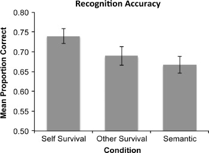

1. [Download : Download full-size image](https://ars.els-cdn.com/content/image/1-s2.0-S1053810012002395-gr1a.jpg)

Fig. 1A. Mean accuracy data for each of the encoding conditions. Error bars represent one standard error from the mean.

### 3.2. Ratings and response latencies

Participants’ tendency to provide high or low ratings for the 30 items in each condition was contrasted to exclude rating bias. Mean rating values were calculated for each participant for the three encoding conditions (see Fig. 1B), and subjected to a one-way ANOVA (Encoding Condition: self, other, semantic). This revealed no significant main effect of condition on fitness ratings *F*(2, 62) = 1.65, *p* = .2, *η*<sup>2</sup> = .05.

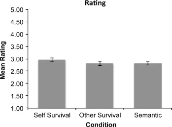

1. [Download : Download full-size image](https://ars.els-cdn.com/content/image/1-s2.0-S1053810012002395-gr1b.jpg)

Fig. 1B. Mean rating data for each of the three encoding conditions. Error bars represent one standard error from the mean.

Average [response latencies](https://www.sciencedirect.com/topics/psychology/response-latency) for the ratings for each condition are shown in Fig. 1C. An ANOVA revealed a significant effect of encoding condition, *F*(2, 62) *=* 6.71, *p* < .005, *η*<sup>2</sup> *=* .18. Response times for self- and other-survival did not differ, *t*(31) = −.74, *p* = .46. However latencies for the semantic task were significantly longer than for self-survival, *t*(31) = −3.43, *p* < .005, and other-survival conditions, *t*(31) = −2.56, *p* = .015. These data suggest that in line with previous research (e.g., Nairne et al., 2007) effortfulness at encoding did not predict memory retention.

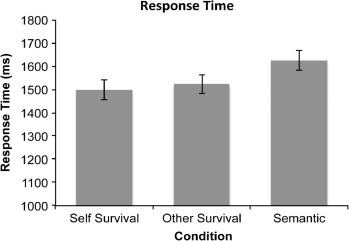

1. [Download : Download full-size image](https://ars.els-cdn.com/content/image/1-s2.0-S1053810012002395-gr1c.jpg)

Fig. 1C. Mean [response latency](https://www.sciencedirect.com/topics/psychology/response-latency) for rating responses during encoding. Error bars represent one standard error from the mean.

## 4. Discussion

The current enquiry asked a simple question: does the memory-enhancing effect of survival-related encoding arise when survival is not personal? Our findings suggest that the answer to this question is no; when participants encoded information in the context of a familiar other person’s survival, no significant memory advantage (over semantic encoding) accrued. In contrast, when information was encoded in the context of personal survival, the standard memory enhancement effect was found. This self-survival advantage was not underpinned by increased fitness ratings, nor was it indexed by differences in response latency compared with the other-survival condition. The current data therefore illustrate that human memory systems may well have been tuned for survival (Nairne et al., 2007), but that this tuning is functionally specific the continued existence of the self.

### 4.1. Linking the self and survival

Given the theoretical overlap between the self and personal survival, it is not surprising that the independent contribution of these processing biases has proved difficult to reliably assess. For example, while Nairne et al. (2007) reported a memory advantage following survival-related encoding but *not* self-referencing, Klein (2012) has shown the effects of the two to be equivalent. Somewhat counter-intuitively, previous research suggested that a survival encoding advantage can be observed for a third person such as a character in a video clip (Kang et al., 2008), and can be equivalent across self-referent and other-referent survival processing conditions (Weinstein et al., 2008). However, in both of these studies participants were only required to process items in relation to the survival of a single referent, perhaps prompting self-projection (i.e., using self-survival thoughts to determine the relevance of items to other referents). Using a within-subjects design may have helped to reduce the influence of self-projection, although some carry-over from self- to other-referent conditions remains possible. However, as any effect of self-projection in the other-referent condition would reduce rather than amplify self-other differences, the significant difference identified in the current study achieves the object of clarifying the impact of referent on survival processing.

What the current study offers is an exploration of survival-based processing from the paradigm perspective of the SRE literature, in which it accepted that to understand the role of the self, self-referent processing should be directly compared with other-referent processing (see Symons & Johnson, 1997). Like the much of the current survival research, early SRE studies compared self-referencing with other encoding strategies such as [semantic processing](https://www.sciencedirect.com/topics/psychology/semantic-processing) and physical properties (e.g., Rogers et al., 1977). It has become more standard to closely match encoding conditions to directly compare self- and other-reference, allowing a more confident assertion of the influence of the self. The value of the current study is that for the first time, to our knowledge, this same approach is applied in the survival literature. Thus we can confidently conclude that the self is a critical element to the survival effect; the encoding context of other people’s survival clearly does not evoke the same processing biases as consideration of one’s own survival.

It is important to note that, like Klein (2012), we do not suggest that the survival effect can be reduced to an artefact of self-referential processing. The body of research demonstrating that grassland encoding contexts and hunter-gatherer goals are particularly effective at eliciting a memory advantage provide strong evidence for an adaptive, functional property of memory (e.g., Nairne et al., 2007, Weinstein et al., 2008). However, what is clear from the current inquiry is that like grassland settings and hunter-gatherer goals, self is a critical element of the encoding context that gives rise to a survival-related memory advantage.

### 4.2. Personal survival goals

The influence of the self in a survival context may reflect the failure of other people’s survival to activate relevant goals. The role of task goals in survival-related encoding has been highlighted by research showing heightened memory when survival-specific goals are evoked (e.g., location for food in a survival task vs. a scavenging game – Nairne et al., 2009). Further, congruent goals can mimic survival effects, such that non-survival-related items that are less likely to be recalled in a survival task, are more likely to be recalled if they are relevant to the goal in the encoding context (e.g., an alarm in the context of a burglary – Butler, Kang, & Roediger, 2009). This congruence effect is not surprising as current goals have been shown in other spheres of memory research to be highly influential in determining encoding effects (see Moskowitz, Gollwitzer, Wasel, & Schaal, 1999). Current task goals effectively prime relevant information in memory, supporting the encoding of congruent over incongruent items. What the current research makes clear is that non-self-relevant processing goals may be ineffective at eliciting a memory advantage; scenarios involving other people’s survival goals are simply less effective encoding devices.

This specificity to self is logical in the context of ecological pressures. There is an advantage in remembering information related to oneself. This importance is reflected in our attention to self-relevant stimuli – whether this comprises catching one’s own name in a group discussion (Cherry, 1953; Moray, 1959), remembering experiences that have happened to oneself (Conway & Dewhurst, 1995), or keeping track of one’s possessions (Cunningham, Turk, MacDonald, & Macrae, 2008). As pointed out elsewhere, “while we are all likely to notice the sound of glass breaking in our vicinity, we are likely to attend to it more, and process it more deeply, when our memory and inference mechanisms identify it as the sound of *OUR* glass breaking.” (Wilson & Sperber, 2004, p. 610 (emphasis added), quoted by Friedman and Ross (2011)). In terms of memory functionality, then, it seems plausible to suggest that the survival effect is driven by a combination of survival-based priming and the frequently activated goal of attending and retaining any information that is relevant to self. Like taking the survival goal out of the encoding context, taking self out of the survival context removes the immediate value of the processing bias and reduces the impact on memory accordingly.

### 4.3. Proximate causes

One advantage of exploring the link between the memory effects associated with survival-based and self-referential encoding is that it offers potential insights into the proximate mechanisms that are likely to drive the memory advantage for survival-based processing. While these are not explored directly in the current inquiry, speculative interpretations suggests a rich potential for future research.

The SRE has been explored widely in behavioral research using a range of encoding and retrieval strategies, and more recent [neuroimaging studies](https://www.sciencedirect.com/topics/psychology/neuroimaging-study) offer new insights (Gray et al., 2004, Turk, Van Bussel, Waiter, et al., 2011, Turk, Van Bussel, Brebner, et al., 2011). The contribution of enriched encoding and relational processing advantages offered by both survival-related and self-referential processing to the survival effect are discussed in depth elsewhere (Burns et al., 2011, Klein, 2012). However, there may be a limit to the effectiveness of a schema-based account of the memory effect, given that participants are unlikely to have sufficient experience or knowledge of survival contexts to form an effective retrieval structure. They are also unlikely to be applying a sufficient degree of stored self-knowledge in the encoding task to foster effective integration of the stimuli with the self-concept. The elaboration and organisation accounts of the SRE (e.g., Klein and Kihlstrom, 1986, Klein and Loftus, 1988; Symons & Johnson, 1997) may therefore fail to offer a complete account of the memory advantage offered by processing information in a self-survival context.

An alternative explanation may come from other accounts of self-processing that highlight the role of increased arousal and attention capture in response to self cues (Turk et al., 2008, Turk, Van Bussel, Waiter, et al., 2011). An emotional basis to the SRE has been proposed, combined with an increase in attentional resources directed to self-relevant information (Bargh, 1982, Gray et al., 2004, Turk, Van Bussel, Brebner, et al., 2011), which combine to enhance memory for self-relevant material even when the self-item association is minimal (Turk et al., 2008). The survival effect has previously been discussed in terms of increased arousal (Weinstein et al., 2008), although Nairne et al. (2007) have argued against such an explanation for lack of plausibility, point out that survival related words are not arousing. Supporting this reasoning, Smeets, Otgaar, Raymaekers, Peters, and Merckelbach (2012) showed that while survival scenarios and acute stress situations both lead to enhanced memory, these effects are independent of one another. It therefore seems unlikely that arousal as a result of the stress of the survival situation itself impacts on memory. However the link between survival and self may render the arousal account more conceivable. Like other aspects of self-processing, considering one’s own survival is likely to be an arousing and attention-capturing encoding context (see Öhman, Flykt, & Esteves, 2001), although at this stage such an account remains speculative and requires empirical attention.

A further avenue for future research would be to examine the interaction between referent and scenario in terms of survival-based processing. The ability to survive is not only a reflection of an organism’s fitness to adapt to the environment (which may include the ability to escape predation by other species), but also about competition for resources within its own species (i.e., competition with other people). However, social and family relationships were critical to ancestral survival (hence Nairne and Pandeirada’s (2008b) suggestion that kinship is another domain in which evolved processing biases would be expected). SRE research has demonstrated that the mnemonic difference between self-referent and other-referent information can be attenuated (even eliminated) when the other-referent is closely connected to self, such as a parent or best friend (Bower and Gilligan, 1979, Symons and Johnson, 1997). It could be predicted, therefore, that if participants in the current experiment had been asked to encode information in the context of their mother’s survival, the pattern of recognition memory performance would have been more in line with self than David Cameron. This prediction notwithstanding, if the function of memory is to enhance fitness for survival, is seems plausible that the maximal benefit of this function would be the continued existence of the individual organism; of the self. Our results demonstrably support this principle.

## 5. Conclusions

There is compelling evidence that a memory advantage can be produced by encoding information in ancestral scenarios, in the context of survival-related goals. Adding to this knowledge, the current inquiry clearly demonstrates that a critical element of the survival-related memory effect is the self: encoding information in the context of survival by other people fails to elicit the standard memory advantage. This finding is compatible with the purported functional adaptations of memory, as well as providing an insight into the mechanisms that might give rise to survival effects on memory. In short, memory has adapted to preferentially process survival information, as long as the survival in question is one’s own.

## Acknowledgments

DJT was supported by a Grant from the European Research Council (202893). We thank Stan Klein and an anonymous reviewer for their helpful comments.

## References

1. Bargh, 1982

   J.A. Bargh

   Attention and automaticity in the processing of self-relevant information

   Journal of Personality and Social Psychology, 43 (1982), pp. 425-436

   [View in Scopus](https://www.scopus.com/inward/record.url?eid=2-s2.0-0001391637&partnerID=10&rel=R3.0.0)[Google Scholar](https://scholar.google.com/scholar_lookup?title=Attention%20and%20automaticity%20in%20the%20processing%20of%20self-relevant%20information&publication_year=1982&author=J.A.%20Bargh)
2. Bower and Gilligan, 1979

   G.H. Bower, S.G. Gilligan

   Remembering information related to one’s self

   Journal of Research in Personality, 13 (1979), pp. 420-432

   [View PDF](https://www.sciencedirect.com/science/article/pii/0092656679900059/pdf?md5=84dfa8554f0bec299010286b57509072&pid=1-s2.0-0092656679900059-main.pdf)[View article](https://www.sciencedirect.com/science/article/pii/0092656679900059)[View in Scopus](https://www.scopus.com/inward/record.url?eid=2-s2.0-0000434920&partnerID=10&rel=R3.0.0)[Google Scholar](https://scholar.google.com/scholar?q=Remembering%20information%20related%20to%20ones%20self)
3. Burns et al., 2011

   D.J. Burns, S.A. Burns, A.J. Hwang

   Adaptive memory: Determining the proximate mechanisms responsible for the memorial advantages of survival processing

   Journal of Experimental Psychology: Learning, Memory, and Cognition, 37 (2011), pp. 206-218

   [CrossRef](https://doi.org/10.1037/a0021325)[View in Scopus](https://www.scopus.com/inward/record.url?eid=2-s2.0-79251525178&partnerID=10&rel=R3.0.0)Google Scholar
4. Butler et al., 2009

   A.C. Butler, S.H.K. Kang, H.L. Roediger

   Congruity effects between materials and processing tasks in the survival paradigm

   Journal of Experimental Psychology: Learning, Memory and Cognition, 35 (2009), pp. 1477-1486

   [CrossRef](https://doi.org/10.1037/a0017024)[View in Scopus](https://www.scopus.com/inward/record.url?eid=2-s2.0-71649103439&partnerID=10&rel=R3.0.0)Google Scholar
5. Cherry, 1953

   E.C. Cherry

   Some experiments on the recognition of speech, with one and two ears

   Journal of the Acoustical Society of America, 25 (1953), pp. 975-979

   [CrossRef](https://doi.org/10.1121/1.1907229)[Google Scholar](https://scholar.google.com/scholar_lookup?title=Some%20experiments%20on%20the%20recognition%20of%20speech%2C%20with%20one%20and%20two%20ears&publication_year=1953&author=E.C.%20Cherry)
6. Clark and Paivio, 2004

   J.M. Clark, A. Paivio

   Extensions of the Paivio, Yuille, and Madigan (1968) norms

   Behavior Research Methods, Instruments, and Computers, 36 (2004), pp. 371-383

   [View in Scopus](https://www.scopus.com/inward/record.url?eid=2-s2.0-12344322945&partnerID=10&rel=R3.0.0)[Google Scholar](https://scholar.google.com/scholar?q=Extensions%20of%20the%20Paivio,%20Yuille,%20and%20Madigan%20%20norms)
7. Conway and Dewhurst, 1995

   M.A. Conway, S.A. Dewhurst

   The self and recollective experience

   Applied Cognitive Psychology, 9 (1995), pp. 1-19

   [CrossRef](https://doi.org/10.1002/acp.2350090102)[View in Scopus](https://www.scopus.com/inward/record.url?eid=2-s2.0-84984134065&partnerID=10&rel=R3.0.0)[Google Scholar](https://scholar.google.com/scholar_lookup?title=The%20self%20and%20recollective%20experience&publication_year=1995&author=M.A.%20Conway&author=S.A.%20Dewhurst)
8. Cunningham et al., 2008

   S.J. Cunningham, D.J. Turk, L.M. MacDonald, C.N. Macrae

   Yours or mine? Ownership and memory

   Consciousness and Cognition, 17 (2008), pp. 312-318

   [View PDF](https://www.sciencedirect.com/science/article/pii/S105381000700030X/pdfft?md5=dc531290e79936e85fc7f0f040f1ad4b&pid=1-s2.0-S105381000700030X-main.pdf)[View article](https://www.sciencedirect.com/science/article/pii/S105381000700030X)[View in Scopus](https://www.scopus.com/inward/record.url?eid=2-s2.0-40749111972&partnerID=10&rel=R3.0.0)[Google Scholar](https://scholar.google.com/scholar?q=Yours%20or%20mine%20Ownership%20and%20memory)
9. Foley, 1995

   R. Foley

   The adaptive legacy of human evolution: A search for the environment of evolutionary adaptedness

   Evolutionary Anthropology: Issues, News, and Reviews, 4 (1995), pp. 194-203

   [View in Scopus](https://www.scopus.com/inward/record.url?eid=2-s2.0-11944265577&partnerID=10&rel=R3.0.0)Google Scholar
10. Friedman and Ross, 2011

    Friedman, O., & Ross, H. (2011). Twenty-one reasons to care about the psychological basis of ownership. In H. Ross, & O. Friedman (Eds.), *Origins of ownership of property* (Vol. 132, pp. 1–8). New Directions for Child and Adolescent Development.

    Google Scholar
11. Gray et al., 2004

    H.M. Gray, N. Ambady, W.T. Lowenthal, P. Deldin

    P300 as an index of attention to self-relevant stimuli

    Journal of Experimental Social Psychology, 40 (2004), pp. 216-224

    [View PDF](https://www.sciencedirect.com/science/article/pii/S0022103103000921/pdfft?md5=2566554a74888c549e243bb570c21ffc&pid=1-s2.0-S0022103103000921-main.pdf)[View article](https://www.sciencedirect.com/science/article/pii/S0022103103000921)[View in Scopus](https://www.scopus.com/inward/record.url?eid=2-s2.0-1542720851&partnerID=10&rel=R3.0.0)Google Scholar
12. Greene, 1996

    R.L. Greene

    The influence of experimental design: The example of the Brown-Peterson paradigm

    Canadian Journal of Experimental Psychology, 50 (1996), pp. 240-242

    [CrossRef](https://doi.org/10.1037/1196-1961.50.2.240)[View in Scopus](https://www.scopus.com/inward/record.url?eid=2-s2.0-0030486681&partnerID=10&rel=R3.0.0)[Google Scholar](https://scholar.google.com/scholar_lookup?title=The%20influence%20of%20experimental%20design%3A%20The%20example%20of%20the%20Brown-Peterson%20paradigm&publication_year=1996&author=R.L.%20Greene)
13. Greenwald, 1976

    A.G. Greenwald

    Within-subjects designs: To use or not to use?

    Psychological Bulletin, 83 (1976), pp. 314-320

    [View in Scopus](https://www.scopus.com/inward/record.url?eid=2-s2.0-0000391283&partnerID=10&rel=R3.0.0)[Google Scholar](https://scholar.google.com/scholar?q=Within-subjects%20designs:%20To%20use%20or%20not%20to%20use)
14. Kang et al., 2008

    S.H.K. Kang, K.B. McDermott, S.M. Cohen

    The mnemonic advantage of processing fitness-relevant information

    Memory and Cognition, 36 (2008), pp. 1151-1156

    [View in Scopus](https://www.scopus.com/inward/record.url?eid=2-s2.0-54949122487&partnerID=10&rel=R3.0.0)Google Scholar
15. Klein, 2012

    S.B. Klein

    A role for self-referential processing tasks requiring participants to imagine survival in the Savannah

    Journal of Experimental Psychology: Learning, Memory and Cognition, 38 (2012), pp. 1234-1242

    [CrossRef](https://doi.org/10.1037/a0027636)[View in Scopus](https://www.scopus.com/inward/record.url?eid=2-s2.0-84869071917&partnerID=10&rel=R3.0.0)Google Scholar
16. Klein et al., 2002

    S.B. Klein, L. Cosmides, J. Tooby, S. Chance

    Decisions and the evolution of memory: Multiple systems, multiple functions

    Psychological Review, 109 (2002), pp. 306-329

    [View in Scopus](https://www.scopus.com/inward/record.url?eid=2-s2.0-85047672923&partnerID=10&rel=R3.0.0)Google Scholar
17. Klein and Kihlstrom, 1986

    S.B. Klein, J.F. Kihlstrom

    Elaboration, organization, and the self-reference effect in memory

    Journal of Experimental Psychology: General, 115 (1986), pp. 26-38

    [View in Scopus](https://www.scopus.com/inward/record.url?eid=2-s2.0-0022689044&partnerID=10&rel=R3.0.0)[Google Scholar](https://scholar.google.com/scholar_lookup?title=Elaboration%2C%20organization%2C%20and%20the%20self-reference%20effect%20in%20memory&publication_year=1986&author=S.B.%20Klein&author=J.F.%20Kihlstrom)
18. Klein and Loftus, 1988

    S.B. Klein, J. Loftus

    The nature of self-referent encoding – the contributions of elaborative and organizational processes

    Journal of Personality and Social Psychology, 55 (1988), pp. 5-11

    [Google Scholar](https://scholar.google.com/scholar?q=The%20nature%20of%20self-referent%20encoding%20%20the%20contributions%20of%20elaborative%20and%20organizational%20processes)
19. Moray, 1959

    N. Moray

    Attention in dichotic listening: Affective cues and the influence of instructions

    Quarterly Journal of Experimental Psychology, 11 (1959), pp. 55-60

    [Google Scholar](https://scholar.google.com/scholar_lookup?title=Attention%20in%20dichotic%20listening%3A%20Affective%20cues%20and%20the%20influence%20of%20instructions&publication_year=1959&author=N.%20Moray)
20. Moskowitz et al., 1999

    G.B. Moskowitz, P.M. Gollwitzer, W. Wasel, B. Schaal

    Preconscious control of stereotype activation through chronic egalitarian goals

    Journal of Personality and Social Psychology, 77 (1999), pp. 167-184

    [View in Scopus](https://www.scopus.com/inward/record.url?eid=2-s2.0-0033456787&partnerID=10&rel=R3.0.0)Google Scholar
21. Nairne, 2005

    J.S. Nairne

    The functionalist agenda in memory research

    A.F. Healy (Ed.), Experimental cognitive psychology and its applications, American Psychological Association, Washington, DC (2005), pp. 115-126

    [CrossRef](https://doi.org/10.1037/10895-009)[Google Scholar](https://scholar.google.com/scholar_lookup?title=The%20functionalist%20agenda%20in%20memory%20research&publication_year=2005&author=J.S.%20Nairne)
22. Nairne and Pandeirada, 2008a

    J.S. Nairne, J.N.S. Pandeirada

    Adaptive memory: Is survival processing special?

    Journal of Memory and Language, 59 (2008), pp. 377-385

    [View PDF](https://www.sciencedirect.com/science/article/pii/S0749596X08000545/pdfft?md5=e31613d2d129f7eb2a0eea2d52ea7ad6&pid=1-s2.0-S0749596X08000545-main.pdf)[View article](https://www.sciencedirect.com/science/article/pii/S0749596X08000545)[View in Scopus](https://www.scopus.com/inward/record.url?eid=2-s2.0-50849144026&partnerID=10&rel=R3.0.0)[Google Scholar](https://scholar.google.com/scholar?q=Adaptive%20memory:%20Is%20survival%20processing%20special)
23. Nairne and Pandeirada, 2008b

    J.S. Nairne, J.N.S. Pandeirada

    Adaptive memory: Remembering with a stone age brain

    Current Directions in Psychological Science, 17 (2008), pp. 239-243

    [CrossRef](https://doi.org/10.1111/j.1467-8721.2008.00582.x)[View in Scopus](https://www.scopus.com/inward/record.url?eid=2-s2.0-48449106331&partnerID=10&rel=R3.0.0)[Google Scholar](https://scholar.google.com/scholar_lookup?title=Adaptive%20memory%3A%20Remembering%20with%20a%20stone%20age%20brain&publication_year=2008&author=J.S.%20Nairne&author=J.N.S.%20Pandeirada)
24. Nairne and Pandeirada, 2010

    J.S. Nairne, J.N.S. Pandeirada

    Adaptive memory: Ancestral priorities and the mnemonic value of survival processing

    Cognitive Psychology, 61 (2010), pp. 1-22

    [View PDF](https://www.sciencedirect.com/science/article/pii/S001002851000006X/pdfft?md5=29af999b782c2792da60a3c75e03f1af&pid=1-s2.0-S001002851000006X-main.pdf)[View article](https://www.sciencedirect.com/science/article/pii/S001002851000006X)[View in Scopus](https://www.scopus.com/inward/record.url?eid=2-s2.0-77952742269&partnerID=10&rel=R3.0.0)Google Scholar
25. Nairne et al., 2009

    J.S. Nairne, J.N.S. Pandeirada, K.J. Gregory, J.E. Van Arsdall

    Adaptive memory: Fitness relevance and the hunter-gatherer mind

    Psychological Science, 20 (2009), pp. 740-746

    [CrossRef](https://doi.org/10.1111/j.1467-9280.2009.02356.x)[View in Scopus](https://www.scopus.com/inward/record.url?eid=2-s2.0-66649135344&partnerID=10&rel=R3.0.0)Google Scholar
26. Nairne et al., 2007

    J.S. Nairne, S.R. Thompson, J.N.S. Pandeirada

    Adaptive memory: Survival processing enhances retention

    Journal of Experimental Psychology: Learning, Memory and Cognition, 33 (2007), pp. 263-273

    [CrossRef](https://doi.org/10.1037/0278-7393.33.2.263)[View in Scopus](https://www.scopus.com/inward/record.url?eid=2-s2.0-33947546922&partnerID=10&rel=R3.0.0)[Google Scholar](https://scholar.google.com/scholar_lookup?title=Adaptive%20memory%3A%20Survival%20processing%20enhances%20retention&publication_year=2007&author=J.S.%20Nairne&author=S.R.%20Thompson&author=J.N.S.%20Pandeirada)
27. New et al., 2007

    J. New, L. Cosmides, J. Tooby

    Category-specific attention for animals reflects ancestral priorities, not expertise

    Proceedings of the National Academy of Sciences, 104 (2007), pp. 16598-16603

    [CrossRef](https://doi.org/10.1073/pnas.0703913104)[View in Scopus](https://www.scopus.com/inward/record.url?eid=2-s2.0-36749062427&partnerID=10&rel=R3.0.0)Google Scholar
28. Öhman et al., 2001

    A. Öhman, A. Flykt, F. Esteves

    Emotion drives attention: Detecting the snake in the grass

    Journal of Experimental Psychology: General, 131 (2001), pp. 466-478

    [View in Scopus](https://www.scopus.com/inward/record.url?eid=2-s2.0-85035568153&partnerID=10&rel=R3.0.0)[Google Scholar](https://scholar.google.com/scholar_lookup?title=Emotion%20drives%20attention%3A%20Detecting%20the%20snake%20in%20the%20grass&publication_year=2001&author=A.%20%C3%96hman&author=A.%20Flykt&author=F.%20Esteves)
29. Öhman and Mineka, 2001

    A. Öhman, S. Mineka

    Fear, phobias and preparedness: Toward an evolved module of fear and fear learning

    Psychological Review, 108 (2001), pp. 483-522

    [View in Scopus](https://www.scopus.com/inward/record.url?eid=2-s2.0-85047683645&partnerID=10&rel=R3.0.0)Google Scholar
30. Rogers et al., 1977

    T.B. Rogers, N.A. Kuiper, W.S. Kirker

    Self-reference and the encoding of personal information

    Journal of Personality and Social Psychology, 35 (1977), pp. 677-688

    [View in Scopus](https://www.scopus.com/inward/record.url?eid=2-s2.0-0017530728&partnerID=10&rel=R3.0.0)[Google Scholar](https://scholar.google.com/scholar_lookup?title=Self-reference%20and%20the%20encoding%20of%20personal%20information&publication_year=1977&author=T.B.%20Rogers&author=N.A.%20Kuiper&author=W.S.%20Kirker)
31. Smeets et al., 2012

    T. Smeets, H. Otgaar, L. Raymaekers, M.J.V. Peters, H. Merckelbach

    Survival processing in times of stress

    Psychonomic Bulletin and Review, 19 (2012), pp. 113-118

    [CrossRef](https://doi.org/10.3758/s13423-011-0180-z)[View in Scopus](https://www.scopus.com/inward/record.url?eid=2-s2.0-84856134926&partnerID=10&rel=R3.0.0)Google Scholar
32. Snodgrass and Corwin, 1988

    J.G. Snodgrass, J. Corwin

    Pragmatics of measuring recognition memory: Applications to dementia and amnesia

    Journal of Experimental Psychology: General, 117 (1988), pp. 34-50

    [View in Scopus](https://www.scopus.com/inward/record.url?eid=2-s2.0-0023974908&partnerID=10&rel=R3.0.0)Google Scholar
33. Symons and Johnson, 1997

    C.S. Symons, B.T. Johnson

    The self-reference effect in memory: A meta-analysis

    Psychological Bulletin, 121 (1997), pp. 371-394

    [View in Scopus](https://www.scopus.com/inward/record.url?eid=2-s2.0-0031136732&partnerID=10&rel=R3.0.0)[Google Scholar](https://scholar.google.com/scholar_lookup?title=The%20self-reference%20effect%20in%20memory%3A%20A%20meta-analysis&publication_year=1997&author=C.S.%20Symons&author=B.T.%20Johnson)
34. Turk et al., 2008

    D.J. Turk, S.J. Cunningham, C.N. Macrae

    Self-memory biases in explicit and incidental encoding of trait adjectives

    Consciousness and Cognition, 17 (2008), pp. 1040-1045

    [View PDF](https://www.sciencedirect.com/science/article/pii/S1053810008000299/pdfft?md5=fadcc51fc2482cb427e885d23036567d&pid=1-s2.0-S1053810008000299-main.pdf)[View article](https://www.sciencedirect.com/science/article/pii/S1053810008000299)[View in Scopus](https://www.scopus.com/inward/record.url?eid=2-s2.0-47149096748&partnerID=10&rel=R3.0.0)Google Scholar
35. Turk, Van Bussel, Brebner, et al., 2011

    D.J. Turk, K. Van Bussel, J.L. Brebner, A.S. Toma, O. Krigolson, T.C. Handy

    When “It” becomes “Mine”: Attentional biases triggered by object ownership’

    Journal of Cognitive Neuroscience, 12 (2011), pp. 3725-3733

    [CrossRef](https://doi.org/10.1162/jocn_a_00101)[View in Scopus](https://www.scopus.com/inward/record.url?eid=2-s2.0-80055121317&partnerID=10&rel=R3.0.0)[Google Scholar](https://scholar.google.com/scholar?q=When%20It%20becomes%20Mine:%20Attentional%20biases%20triggered%20by%20object%20ownership)
36. Turk, Van Bussel, Waiter, et al., 2011

    D.J. Turk, K. Van Bussel, G.D. Waiter, C.N. Macrae

    ‘Mine and me: Exploring the neural basis of object ownership’

    Journal of Cognitive Neuroscience, 23 (11) (2011), pp. 3657-3668

    [CrossRef](https://doi.org/10.1162/jocn_a_00042)[View in Scopus](https://www.scopus.com/inward/record.url?eid=2-s2.0-80053502764&partnerID=10&rel=R3.0.0)[Google Scholar](https://scholar.google.com/scholar?q=Mine%20and%20me:%20Exploring%20the%20neural%20basis%20of%20object%20ownership)
37. Weinstein et al., 2008

    Y. Weinstein, J.M. Bugg, H.L. Roediger

    Can the survival recall advantage be explained by basic memory processes?

    Memory and Cognition, 36 (2008), pp. 913-919

    [View in Scopus](https://www.scopus.com/inward/record.url?eid=2-s2.0-46449092131&partnerID=10&rel=R3.0.0)[Google Scholar](https://scholar.google.com/scholar?q=Can%20the%20survival%20recall%20advantage%20be%20explained%20by%20basic%20memory%20processes)

## Cited by (23)

### [Conscious awareness of self-relevant information is necessary for an incidental self-memory advantage](https://www.sciencedirect.com/science/article/pii/S1053810018301727)

- 2018, Consciousness and Cognition

  Citation Excerpt :

  The incidental SRE is suggested to be underpinned by automatic attentional responses to self-relevant information (i.e., “attention-capturing” capacity of self-cues; e.g., Bargh, 1982; Gray, Ambady, Lowenthal, & Deldin, 2004; Moray, 1959) that promote enhanced encoding of stimuli co-occurring with the self-relevant cues in the environment (Cunningham et al., 2014; Turk et al., 2008; Turk et al., 2011; see Turk et al., 2013, for the role of attention during encoding in the emergence of the SRE; see Gronau, Cohen, & Ben-Shakhar, 2003; Kawahara & Yamada, 2004; Kim et al., 2018, for the role of task context in determining the likelihood of a self-advantage in attention and memory). Indeed, as suggested elsewhere, one of the major functions of the self-system may be to ensure that information of potential relevance to the self is preferentially attended and retained (Cunningham, Brady-Van den Bos, Gill, & Turk, 2013; Turk et al., 2008). A recent revival of research interests in self-related biases in cognition has witnessed several demonstrations of the “prioritized” processing of self-relevant information in unconscious stages of information processing hierarchy (for self-face: Geng, Zhang, Li, Tao, & Xu, 2012; Pannese & Hirch, 2010, 2011; for self-name: Alexopoulos, Muller, Ric, & Marendaz, 2012; Maoz, Breska, & Ben-Shakhar, 2012; Pfister, Pohl, Kiesel, & Kunde, 2012; Tacikowski, Berger, & Ehrsson, 2017; for self-associated geometric shapes: Macrae, Visokomogilski, Golubickis, Cunningham, & Sahraie, 2017; Sui & Humphreys, 2017; but see Noel, Blanke, Serino, & Salomon, 2017; Stein, Siebold, & Van Zoest, 2016; Tacikowski & Ehrsson, 2016).

### [Applying Self-Processing Biases in Education: Improving Learning Through Ownership](https://www.sciencedirect.com/science/article/pii/S2211368117300037)

- 2018, Journal of Applied Research in Memory and Cognition

  Citation Excerpt :

  Both experiments showed a reliable memory advantage for items “owned” by oneself, rather than owned by another person or by no-one. This is consistent with previous research suggesting that assigning ownership over stimuli creates a self-referent encoding bias, resulting in enhanced recollection (e.g., Cunningham et al., 2008, 2011; Cunningham, Vergunst, et al., 2013; Ross et al., 2011; Van den Bos, Cunningham, & Turk, 2010). The current demonstration that applying the ownership effect in an educational context offers a high-impact application is a valuable step forward for this line of research.

### [Survival processing versus self-reference: A memory advantage following descriptive self-referential encoding](https://www.sciencedirect.com/science/article/pii/S0749596X17300037)

- 2017, Journal of Memory and Language

  Citation Excerpt :

  As discussed above, however, Nairne et al. used the autobiographical self-reference task rather than the descriptive task. Nairne et al. also used a within-subjects design in which participants took part in both the survival and the self-reference conditions (within-subjects manipulations of self versus survival processing were also used by Cunningham et al., 2013; Kostic et al., 2012; Weinstein et al., 2008). As discussed by Conway et al. (2001), however, within-subject designs are problematic for the self-reference effect because of the danger of carry-over effects.

### [Testing the Modulation of Self-Related Automatic and Others-Related Controlled Processing by Chronotype and Time-of-Day](https://doi.org/10.2139/ssrn.4362741)

- 2023, SSRN

### [The relevance of familiarity in the context of self-related information processing](https://doi.org/10.1177/17470218231154884)

- 2023, Quarterly Journal of Experimental Psychology

### [Varying retrieval conditions to study survival processing](https://doi.org/10.1080/09658211.2022.2080226)

- 2022, Memory

[View all citing articles on Scopus](http://www.scopus.com/scopus/inward/citedby.url?partnerID=10&rel=3.0.0&eid=2-s2.0-84873862406&md5=c87899bfe833c575f908a79612f9551)

**<sup>1</sup>**

Permanent address.

**<sup>2</sup>**

An accuracy score was calculated to correct for guessing following the procedure outlined by Snodgrass and Corwin (1988): *Hit Rate* = (Number of Hits + .5)/(Total possible hits + 1). *False Alarm Rate* = (number of false alarms +.5)/(Total possible false alarms +1). *Accuracy score* = Hit Rate − False Alarm Rate.

[View Abstract](https://www.sciencedirect.com/science/article/abs/pii/S1053810012002395)

Copyright © 2013 Elsevier Inc. All rights reserved.

  [View PDF](https://www.sciencedirect.com/science/article/pii/S0022519317303090/pdfft?md5=5ace98835d034034660fc8706ec04416&pid=1-s2.0-S0022519317303090-main.pdf)

### [Adaptive memory: Temporal, semantic, and rating-based clustering following survival processing](https://www.sciencedirect.com/science/article/pii/S0749596X16301826)

- Journal of Memory and Language, Volume 93, 2017, pp. 304-314

  James S. Nairne, …, Melissa Lehman

  [View PDF](https://www.sciencedirect.com/science/article/pii/S0749596X16301826/pdfft?md5=d5f3e2cf8e6c01c2beb92cfea820a326&pid=1-s2.0-S0749596X16301826-main.pdf)

### [Self-referential processing in unipolar depression: Distinct roles of subregions of the medial prefrontal cortex](https://www.sciencedirect.com/science/article/pii/S0925492716300762)

- Psychiatry Research: Neuroimaging, Volume 263, 2017, pp. 8-14

  Yu Li, …, Jiang Qiu

  [View PDF](https://www.sciencedirect.com/science/article/pii/S0925492716300762/pdfft?md5=12c028634b3ad88093eb04f92cda7f42&pid=1-s2.0-S0925492716300762-main.pdf)

Citations

Captures

Mentions

- References: 2

Social Media

- Shares, Likes & Comments: 44

[View details](https://plu.mx/plum/a/?doi=10.1016/j.concog.2012.12.005&theme=plum-sciencedirect-theme&hideUsage=true)